# ShockCordAnalysis

## Introudction

This document serves to simulate the shock-cord system that is a subsystem of the rocket's recovery system. This is done to try and numerically justify the switch to a shorter and thinner shock cord. It must be noted that a vast number of simplifying assumptions are made in this document, and the modelling was used only as a rough estimate on the effect that a changing shock cord would have on the system.

*Prepared by Artem Sotnikov*

Resources:

https://www.reddit.com/r/rocketry/comments/jgxh99/how_do_you_calculate_the_deceleration_when_going/

https://www.animatedknots.com/rope-properties

The goal of the notebook is to provide the backrgound to simulate a dynamic system for the opening of the parachute (which is done in simulink)

For a background on dynamic systems modelling, see the following textbook: Palm, System Dynamics 4th Edition

For a background on the design of parachute recovery systems, the following resource is heavily used: Parachute Recovery Systems Design Manual, by T. W. Knacke (1992)

In the dynamic system, two points are taken under analysis, one at the rocket, and the other at SLPOC (shroud line point of confluence), where the two points thus exist on opposite sides of the shock cord. Further simplifying, all other elastic effects are neglected, and the rocket is treated as a lumped mass not subject to any drag forces by itself. A diagram is shown below, with all forces, directions, and approximate masses shown:

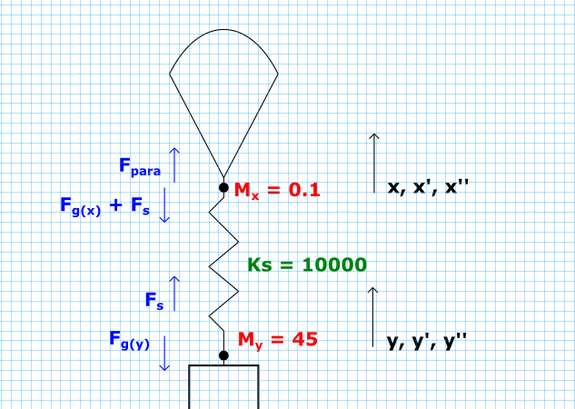

The $K_s$ value (shown as approximate in the diagram above) can be determined both analytically and experimentally. Experimental values yield somewhere in the area of 100 - 150 N/m. For kevlar, the tensile modulus is around 112 GPa (https://www.matweb.com/search/datasheet.aspx?MatGUID=77b5205f0dcc43bb8cbe6fee7d36cbb5&ckck=1). With k = AE/L, for 60 ft (19.93m as measured) 1/2" kevlar the k value in N/m can be calculated (with the simplifying assumption that the shock ord is a long cylider, which isn't actually true in reality).

```python
import math
A = 0.25*math.pi*((0.5)*0.0254)**2
print('A = '  + str(A))
L = 19.93;
E = 112 * 10e9;
k = A*E/L
```

```
A = 0.00012667686977437442
```

```
7118820.579392843
```

This value is clearly non-physical, as even conceded by an online resource. Based on this 'ropes' resource, it lists a more realistic practical value at 0.25 ton/cm^2 for a 1% stretch. This can be converted into a K value: $F = k x \therefore k = F / x$, and considering the length value of 19.93 m (as calculated above, the area of the rope in indeed one square centimeter)

```python
import math
dx = 19.93 * 0.01;
F = 0.25 * 9806;
k = F/dx
```

```
12300.551931761163
```

This does not entirely line up with experimental tests, which records the shock cord as being much more easy to stretch initially (10 -15 N per 0.14m stretch), yielding a K of:

```python
k = 15/0.14
```

```
107.14285714285714
```

As a result of this, a very broad range of K value must unfortunately be considered.

From the dynamic system, a system of differential equations can be derived using F = ma:

$ \ddot x = (F_{para} - m_x g - K_s (x - y)) \cdot m_x^{-1} $

$ \ddot y = (K_s (x - y) - m_y g) \cdot m_y^{-1} $

Where the force of the parachute can be further resolved into:

$ \ddot x = (\frac{1}{2} (\rho_{1500 ft}) \dot{x} (CdSo(t)) - m_x g - K_s (x - y)) \cdot m_x^{-1} $

And the initial conditions for such a system are as follows:

$x(0) = 0 $

$y(0) = 0 $

The latter is not actually zero but rather equivalent to the stretch that is produced by the reefed stage. However, calculating this exactly is not necessary, as the inaccurate initial conditions merely result in some oscillations near the start of the simulation.

$ \dot x (0) = \dot y (0) = V_{descent} $

The system can be then simulated to see how the accelerations and forces change when the spring characteristics of the shock cord change. By modulating the exact behavoir of the CdSo function, various opening profiles can also be explored in this context.

The simulink model that was constructed to simulate this dynamic system is as follows:

[figure not shown]

Which exactly captures the system of differential equations as described above. Two models are coded in for the opening. Given an unreefed drag area of 13.9355 m^2 (known from past testing), the functions are as follows:

$ CdSo_{exponential} = 13.9355 \cdot (1 - e^{-t / \tau_{exp}})$

up to $\tau_{lin} t = 1$

$ CdSo_{linear} = 13.9355 \cdot (t / \tau_{lin} )$ And thereafter

$ CdSo_{linear} = 13.9355 $

Knacke's Recovey Systems Deisgn Manual suggests some values for these time constants (pg 5-61 or 140 in the pdf):

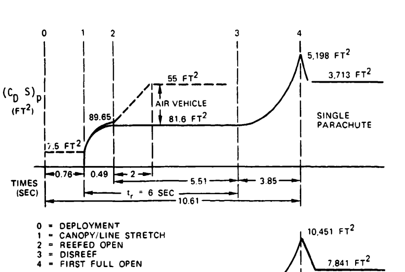

Making $\tau_{lin} = 2$. During testing, values closer to 0.5 seconds were observed howeever, making the realistic value: Making $\tau_{lin} = 0.5$

Exponential time constants would roughly approximate these values via T_exp = T_lin / 2

[figure not shown]

Scope catures of the behavoir are used to display and analyze the kinematic response of the system (shown in units of SI MGS). Positions are in meters, velocities in m/s, accelerations in m/s^2. CdSo is in m^2.

Using the rough experimental value of 100 for the K gives somewhat non-physical behavoir of the sysem and almost 100% stretch:

(linear)

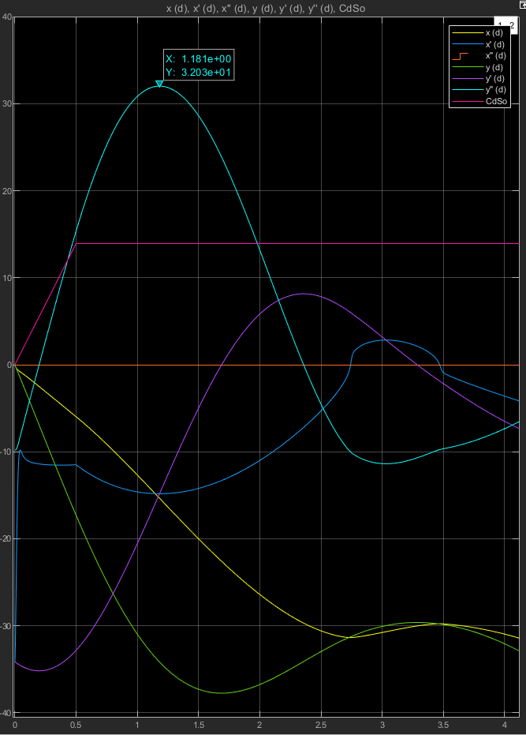

(exponential)

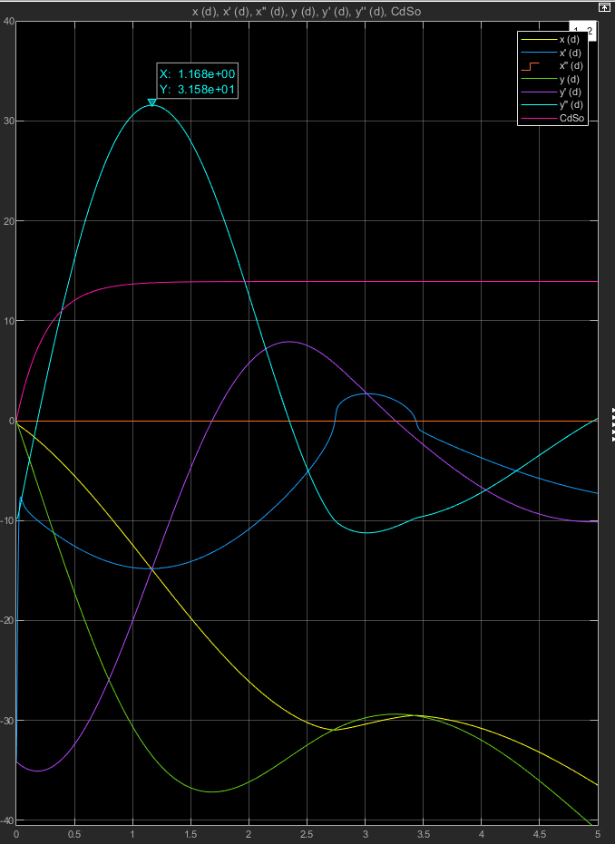

Using the calculated value of K based on the 'realistic' estimates (k = 12300) on the online resource yields something more physically reasonable:

(linear)

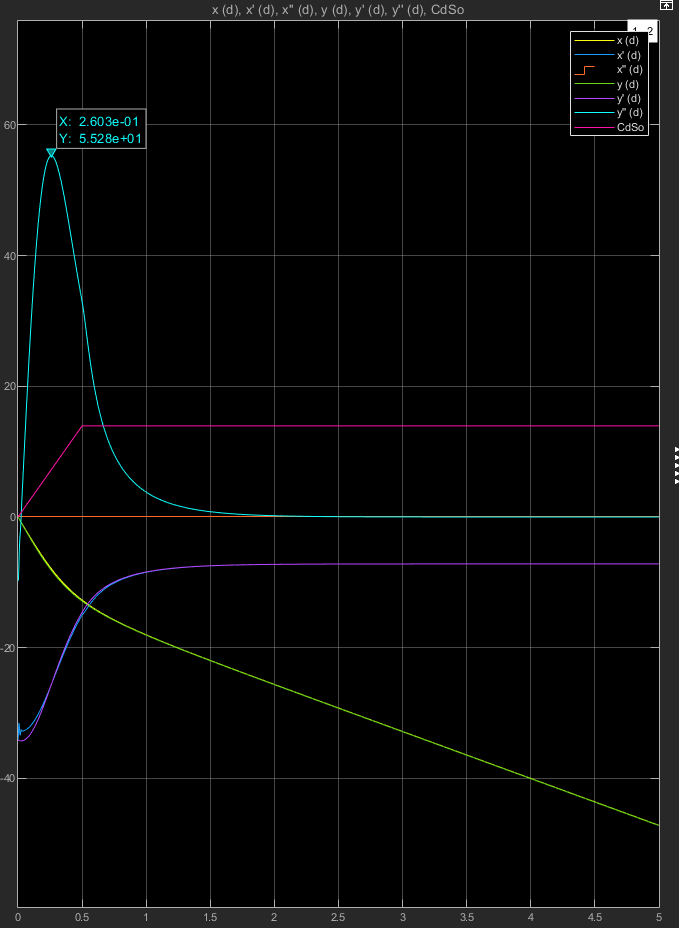

(exponential)

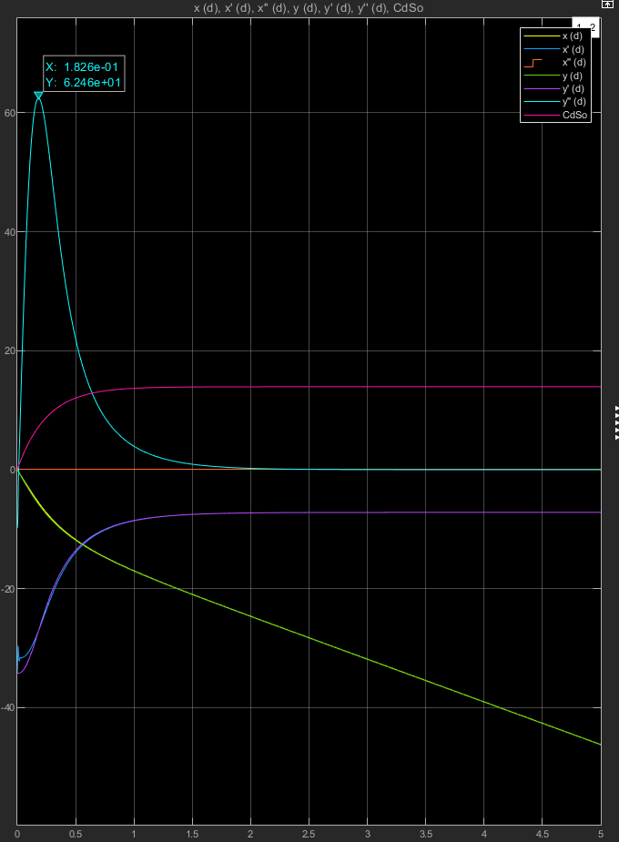

The values produced by raw calculation of fiber properties are not considered due to the fact that they are clearly non-physical

When switching to a thinner and shorter shock cord, the value of k would be affected as follows:

$K = A E / L$ $\therefore k_m = (A_{new} / A_{old}) (L_{old} / L_{new}) $

Given the proposed new length and diameter of the shock cord at 20ft long and 7/16" in diameter:

```python
k_m = (((7/16)**2)/(0.5**2)) * ((19.93)/(20/3.281))
```

```
2.5032235703125
```

Which can be put as an additional gain term in the model

Running all four cases as considered above with the modified k values yields:

(low-experimental K linear cdso):

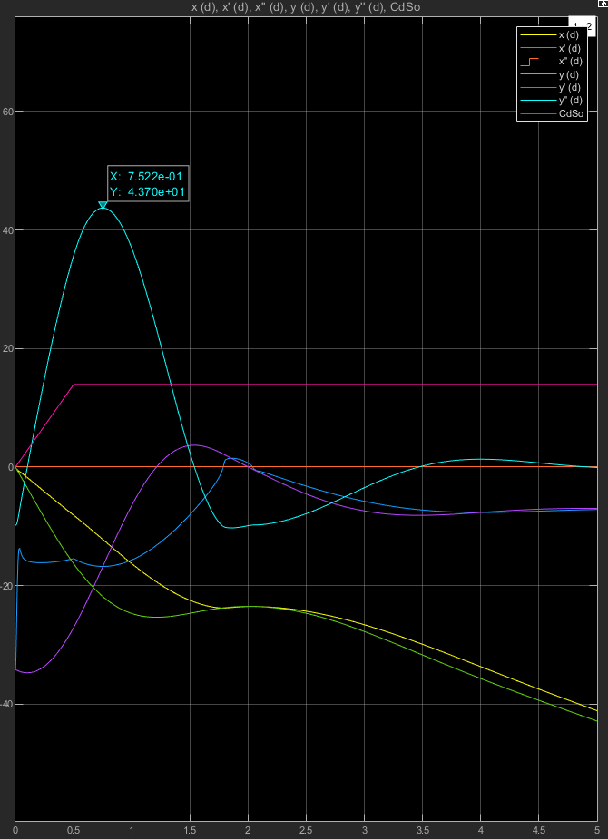

(low-experimental K exponential cdso):

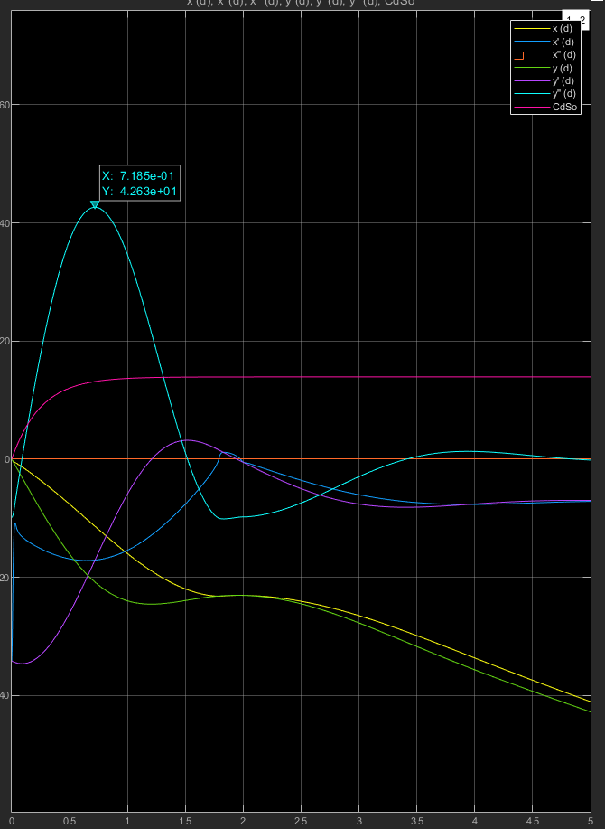

(high-theoretical K linear cdso)

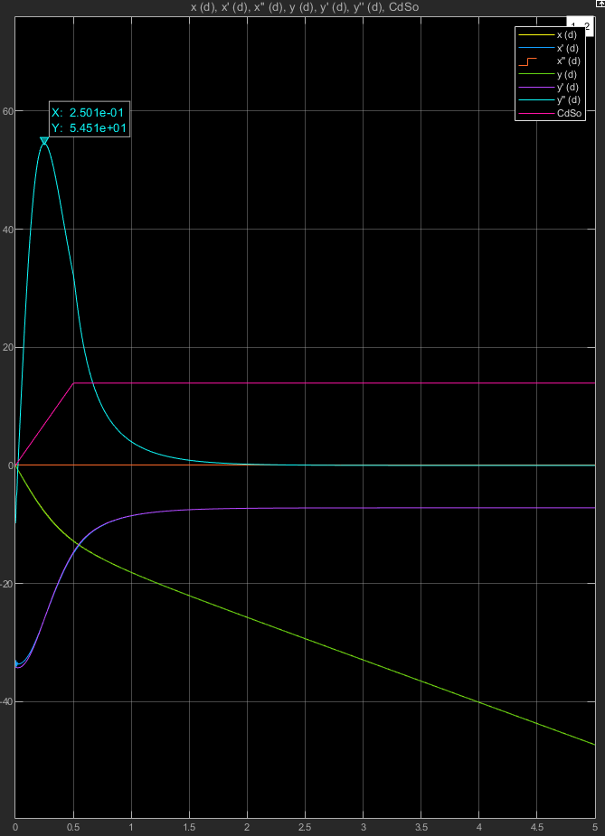

(high-theoretical K exponential cdso)

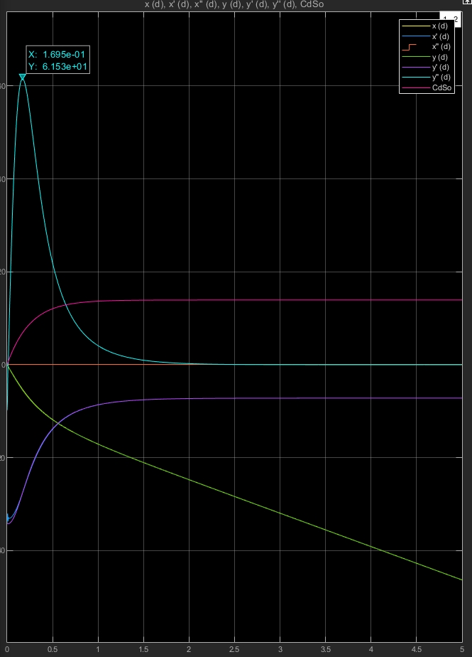

Further exploring the perfromance by testing the sensitivity of the time constant by changing T_lin to 0.3 instaed of 0.5:

Here it can be seen that it has a significant effect on the theoretical shock load for both shock cords using the high-theretical k baseline:

(new - higher k)

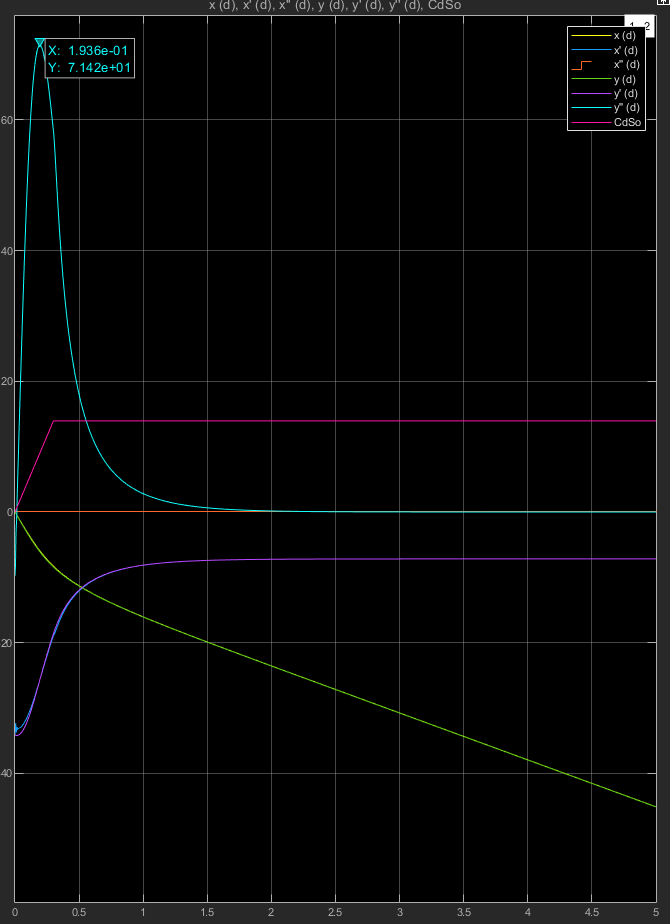

(new - lower k)

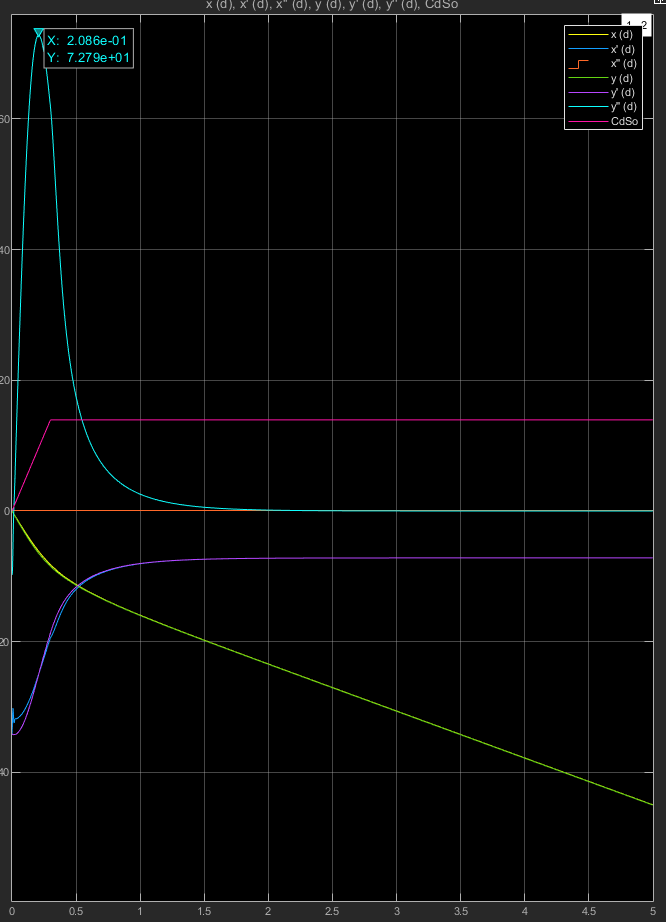

Overall, the general trend of the simulations in simulink seem to suggest that changing to a different shock cord is justified. The rough estimates for the shock values do not increasing alarmingly enough to warrant excessive concern. Compared to the significant advantages that stand to be agiend from the shorter shock cord, the switch should be made.